# Predicting NBA Game Outcomes

S&DS 361

2024-02-06

## Review Simple Linear Regression

The simple linear regression model can be written

$$Y = \beta_0 + \beta_1 x + \epsilon,
\quad \epsilon \sim N(0, \sigma^2)$$

We can think of this as a deterministic relationship that is linear ($\beta_0 + \beta_1 x$), plus some non-deterministic/randomness component $\epsilon$.

We use a capital $Y$ for the outcome to indicate that $Y$ is a random variable, which it is since it equals a constant plus a random variable ($\epsilon$).

To understand this further, let’s use $x^*$ to denote a particular value of $x$. For a given $x^*$, we have

1. $E(Y|x^*) = E(\beta_0 + \beta_1 x^* + \epsilon) = \beta_0 + \beta_1 x^* + E(\epsilon) = \beta_0 + \beta_1 x^*$
2. $V(Y|x^*) = V(\beta_0 + \beta_1 x^* + \epsilon) = V(\epsilon) = \sigma^2$
3. $Y$ is normally distributed (since it is constant + $\epsilon$ and $\epsilon$ is normal)

So for any given $x^*$, we have that $Y \sim N(\beta_0 + \beta_1 x^*, \sigma^2)$.

## Review linear regression assumptions

- Linearity: The relationship between the predictors and the outcome is linear.
- Independence: The error are independent.
- Normality: The outcome is normally distributed at each x.
- Constant variance: The variance of the outcome is equal for all x.

## NBA games data

```r
d = readRDS('data/games.rds')

## Basketball
nba = d %>%
  filter(lg == 'nba',
         season %in% 1990:2023,
         season.type == 'reg') %>%
  select(date, away, home,
         ascore, hscore, season, gid)
head(d)
```

```
##         date away home ascore hscore  lg season season.type      gid
## 1 2021-10-19  BKN  MIL    104    127 nba   2022         reg 22100001
## 2 2021-10-19  GSW  LAL    121    114 nba   2022         reg 22100002
## 3 2021-10-20  OKC  UTA     86    107 nba   2022         reg 22100011
## 4 2021-10-20  SAC  POR    124    121 nba   2022         reg 22100013
## 5 2021-10-20  DEN  PHX    110     98 nba   2022         reg 22100012
## 6 2021-10-20  ORL  SAS     97    123 nba   2022         reg 22100010
##                     gkey
## 1 nba.2021-10-19.BKNvMIL
## 2 nba.2021-10-19.GSWvLAL
## 3 nba.2021-10-20.OKCvUTA
## 4 nba.2021-10-20.SACvPOR
## 5 nba.2021-10-20.DENvPHX
## 6 nba.2021-10-20.ORLvSAS
```

```r
da = nba %>% select(date, away, ascore, home, hscore, season, gid) %>% mutate(ha = 'away')
dh = nba %>% select(date, home, hscore, away, ascore, season, gid) %>% mutate(ha = 'home')
colnames(da) = c('date', 'team', 'score',  'opp', 'opp.score', 'season', 'gid', 'ha')
colnames(dh) = c('date', 'team', 'score',  'opp', 'opp.score', 'season', 'gid', 'ha')
db = bind_rows(da, dh) %>%
  arrange(date, gid)
head(db)
```

```
##         date team score opp opp.score season      gid   ha
## 1 1989-11-03  HOU    88 LAC       102   1990 28900001 away
## 2 1989-11-03  LAC   102 HOU        88   1990 28900001 home
## 3 1989-11-03  IND   126 ATL       103   1990 28900002 away
## 4 1989-11-03  ATL   103 IND       126   1990 28900002 home
## 5 1989-11-03  GOS   106 PHX       136   1990 28900003 away
## 6 1989-11-03  PHX   136 GOS       106   1990 28900003 home
```

First let’s create a column that represents how good the team was in the previous season. We’ll start by finding the average score and score allowed for each team in each season.

```r
ds = db %>%
  group_by(team, season) %>%
  summarise(avg.score = mean(score),
            avg.opp.score = mean(opp.score))
head(ds,2)
```

```
## # A tibble: 2 × 4
## # Groups:   team [1]
##   team  season avg.score avg.opp.score
##   <chr> <chr>      <dbl>         <dbl>
## 1 ATL   1990        109.          108.
## 2 ATL   1991        110.          109.
```

```r
db = db %>%
  mutate(prev.season = as.character(as.numeric(season) - 1))
head(db,2)
```

```
##         date team score opp opp.score season      gid   ha prev.season
## 1 1989-11-03  HOU    88 LAC       102   1990 28900001 away        1989
## 2 1989-11-03  LAC   102 HOU        88   1990 28900001 home        1989
```

We want to add columns for the previous season’s average score for the `team` in each row. We can do this by adding a `prev.season` column to `db` and joining `ds` with `db`.

```r
dd = db %>%
  left_join(ds,
            by = c('team',
                   'prev.season' = 'season')) %>%
  filter(!is.na(avg.score),
         score != 0) %>%
  rename(avg.score.prev = avg.score)
head(dd)
```

```
##         date team score opp opp.score season      gid   ha prev.season
## 1 1990-11-02  HOU    89 POR        90   1991 29000001 away        1990
## 2 1990-11-02  POR    90 HOU        89   1991 29000001 home        1990
## 3 1990-11-02  GOS   162 DEN       158   1991 29000002 away        1990
## 4 1990-11-02  DEN   158 GOS       162   1991 29000002 home        1990
## 5 1990-11-02  NYK   134 CHH       130   1991 29000003 away        1990
## 6 1990-11-02  CHH   130 NYK       134   1991 29000003 home        1990
##   avg.score.prev avg.opp.score
## 1       106.7317      105.2683
## 2       114.2073      107.8902
## 3       116.2683      119.4024
## 4       114.5976      113.1829
## 5       108.2805      106.8659
## 6       100.3902      108.2073
```

If we’d like, we can also make adjustments for the opponent and the season. If, for example, the opponent allowed 1 more point than league average, we’ll adjust average score up by 1.

```r
dl = db %>%
  group_by(season) %>%
  summarise(lg.avg.score = mean(score))
head(dl,2)
```

```
## # A tibble: 2 × 2
##   season lg.avg.score
##   <chr>         <dbl>
## 1 1990           107.
## 2 1991           106.
```

```r
ds = ds %>%

  left_join(dl,
            by = 'season') %>%

  mutate(score.above.lg.avg     = avg.score     - lg.avg.score,
         opp.score.above.lg.avg = avg.opp.score - lg.avg.score)
```

```r
dd = dd %>%
  left_join(ds %>% select(team,
                          season,
                          opp.score.above.lg.avg),
            by = c('opp' = 'team',
                   'prev.season' = 'season')) %>%
  left_join(dl,
            by = 'season') %>%
  left_join(dl,
            by = c('prev.season' = 'season'),
            suffix = c('', '.prev')) %>%
  rename(opp.score.above.lg.avg.prev = opp.score.above.lg.avg) %>%
  mutate(avg.score.prev.adj =
           avg.score.prev +
           opp.score.above.lg.avg.prev +
           lg.avg.score - lg.avg.score.prev) %>%

  select(date, team, score,
         opp, opp.score, season,
         ha, gid,
         avg.score.prev, avg.score.prev.adj)
head(dd,2)
```

```
##         date team score opp opp.score season   ha      gid avg.score.prev
## 1 1990-11-02  HOU    89 POR        90   1991 away 29000001       106.7317
## 2 1990-11-02  POR    90 HOU        89   1991 home 29000001       114.2073
##   avg.score.prev.adj
## 1           106.9463
## 2           111.7999
```

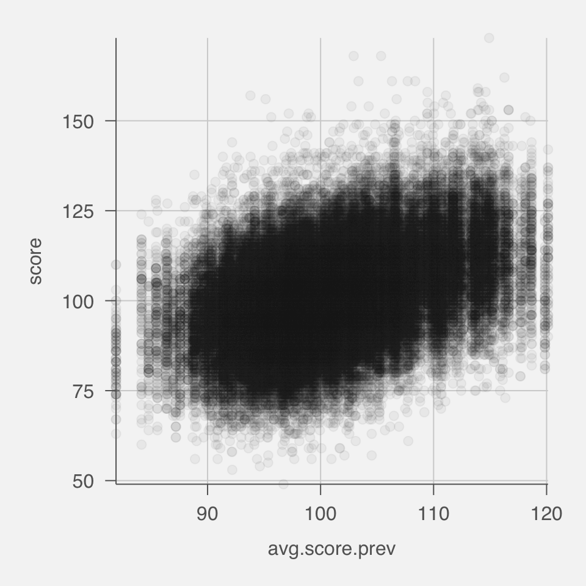

```r
g = ggplot(dd,
           aes(x = avg.score.prev,
               y = score)) +
  geom_point(color = pubdarkgray,
             alpha = 0.05)
g %>%
  pub(type = 'scatter')
```

Note that `score` appears fairly normally distributed.

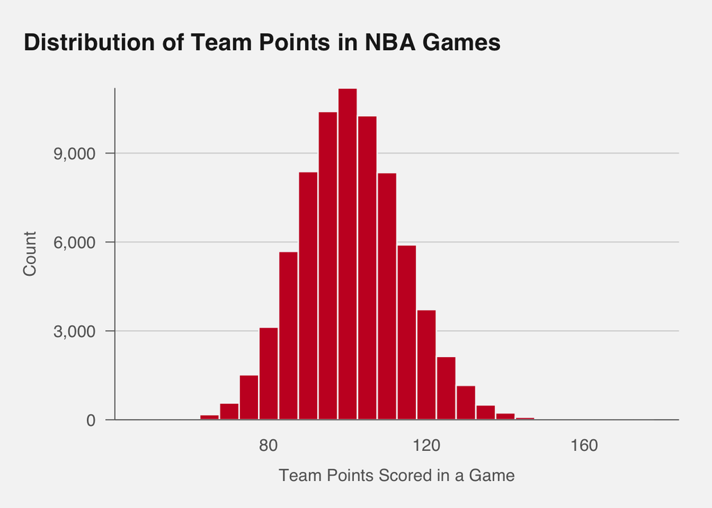

```r
title = 'Distribution of Team Points in NBA Games'
g  = ggplot(dd, aes(x = score))+
  geom_histogram(fill = pubred,
                 color = pubbackgray,
                 binwidth = 5) +
  labs(title    = title,
       x = 'Team Points Scored in a Game',
       y = 'Count')

g %>%
  pub(type = 'hist')
```

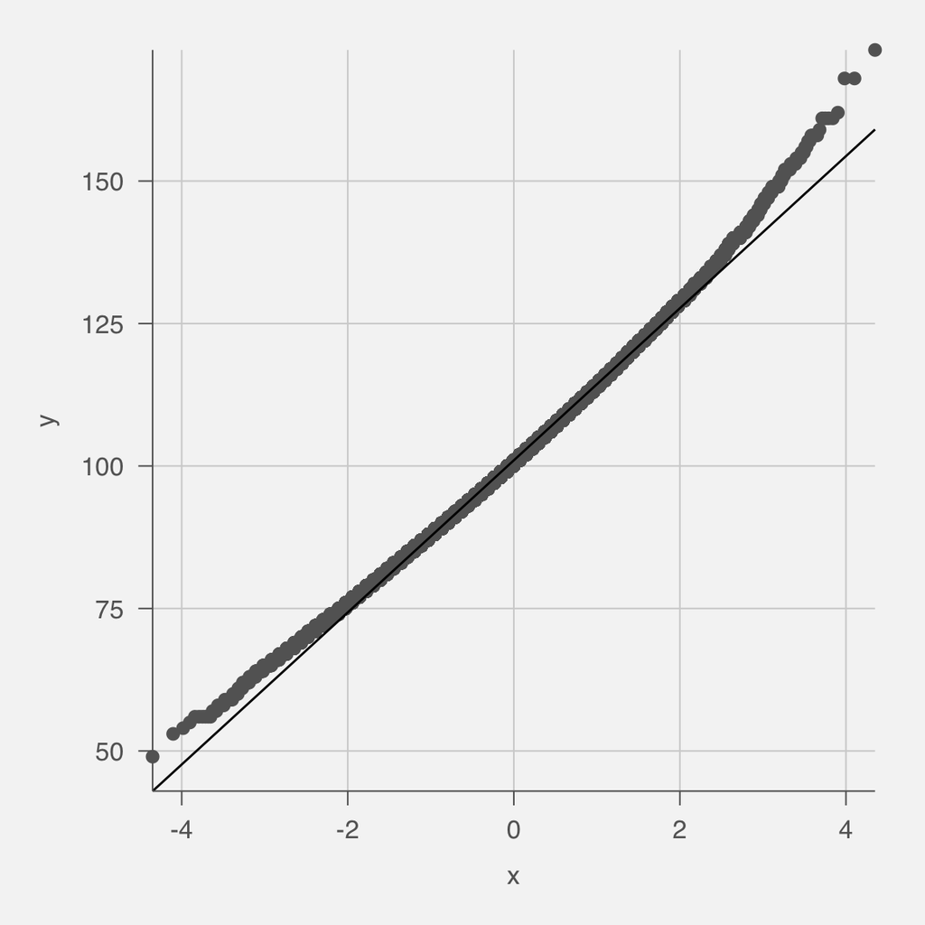

```r
g  = ggplot(dd,
            aes(sample = score))+
  geom_qq() +
  geom_qq_line()

g %>%
  pub(type = 'scatter')
```

The tails don’t look perfect, but this will be better later when we include more information than simply average points from the previous season.

Also, what we actually need is not that `score` is normally distributed, but that `score` is normally distributed *for a given set of predictors*, or in this case, for a given value of `avg.score.prev`. Note that if we look at a single value of `avg.score.prev`, there may be few or no observations that have that exact value of `avg.score.prev`, so we will look at small ranges of `avg.score.prev`.

If we look at the distribution of `score` for different subsets of our predictor `avg.score.prev`, it should look roughly normal for each subset. We can eyeball this by looking at the scatter plot. But let’s actually plot it, in part to practice data summarization and visualization, and in part because we’ll want to create similar visualizations later in other situations in which it might be less easy to eyeball.

We can bin our data using the function `cut_interval`.

```r
dd = dd %>%
  mutate(bin = cut_interval(avg.score.prev,
                            length = 5))
head(dd)
```

```
##         date team score opp opp.score season   ha      gid avg.score.prev
## 1 1990-11-02  HOU    89 POR        90   1991 away 29000001       106.7317
## 2 1990-11-02  POR    90 HOU        89   1991 home 29000001       114.2073
## 3 1990-11-02  GOS   162 DEN       158   1991 away 29000002       116.2683
## 4 1990-11-02  DEN   158 GOS       162   1991 home 29000002       114.5976
## 5 1990-11-02  NYK   134 CHH       130   1991 away 29000003       108.2805
## 6 1990-11-02  CHH   130 NYK       134   1991 home 29000003       100.3902
##   avg.score.prev.adj       bin
## 1           106.9463 (105,110]
## 2           111.7999 (110,115]
## 3           121.7755 (115,120]
## 4           126.3243 (110,115]
## 5           108.8121 (105,110]
## 6            99.5804 (100,105]
```

Let’s plot the distribution of score separately for every bin.

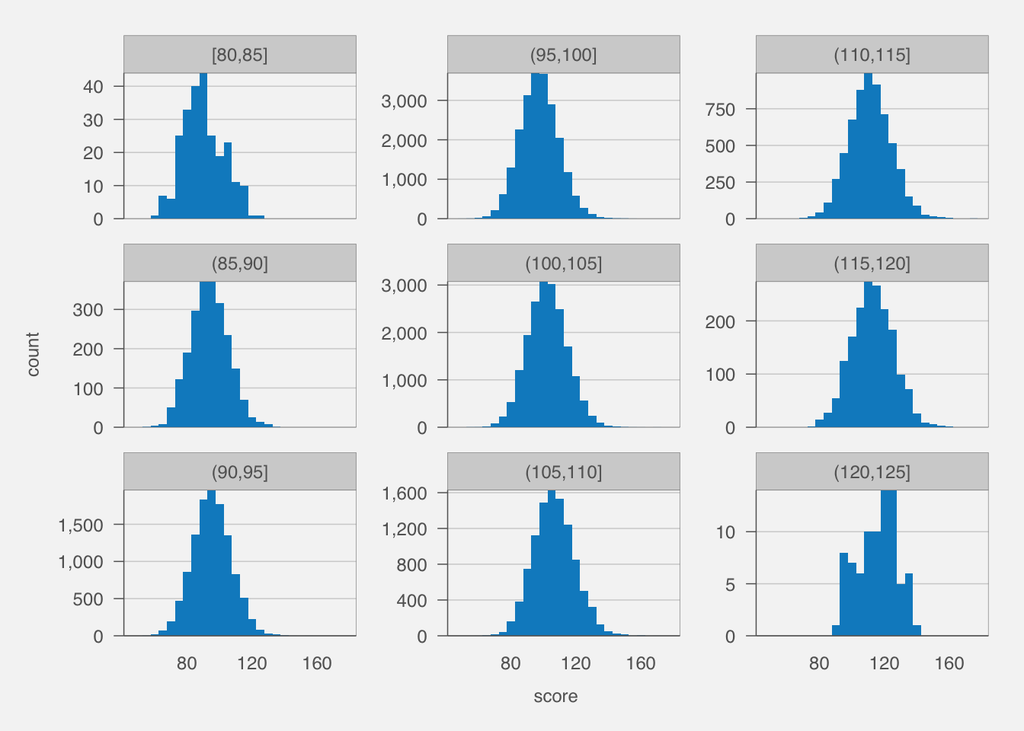

```r
g = ggplot(dd,
           aes(x = score))+
  geom_histogram(binwidth = 5)+
  facet_wrap(~bin,
             scales = 'free_y',
             dir = 'v')

g %>%
  pub(type = 'hist',
      facet = T,
      base_size = 9)
```

Hmm, it would be nice to have a vertical line showing the mean for every bin.

```r
bin.means = dd %>%
  group_by(bin) %>%
  summarise(mean.score = mean(score),
            var.score = var(score),
            n = n())
bin.means
```

```
## # A tibble: 9 × 4
##   bin       mean.score var.score     n
##   <fct>          <dbl>     <dbl> <int>
## 1 [80,85]         89.9      155.   246
## 2 (85,90]         93.7      136.  2232
## 3 (90,95]         95.2      140. 11589
## 4 (95,100]        97.4      140. 22137
## 5 (100,105]      102.       147. 18993
## 6 (105,110]      106.       158. 10271
## 7 (110,115]      111.       164.  6221
## 8 (115,120]      113.       167.  1781
## 9 (120,125]      115.       156.    82
```

We see that the means increase with the bins (except for bins with small sample size issue). We also, unfortunately, see that the variances seem to increase as well. Note that if we think our outcome is roughly normal for every $x$, and we expect the variance to be roughly equal for all subsets. The constant variance assumption in linear regression is violated somewhat, but let’s go with it for now. This will get better when we consider more information that simply `avg.score.prev`.

Let’s plot our histograms with the vertical lines.

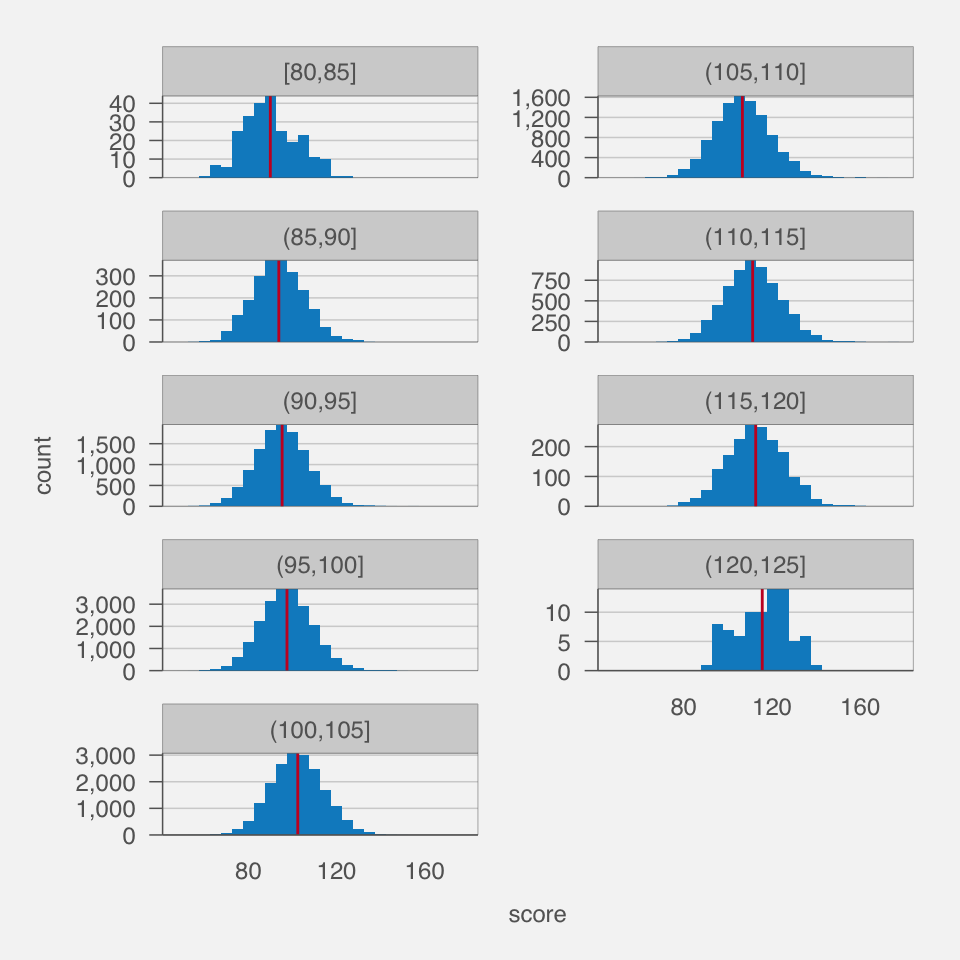

```r
g = ggplot(data = dd,
       aes(x = score))+
  geom_histogram(binwidth = 5) +
  geom_vline(data = bin.means,
             aes(xintercept = mean.score),
             color = pubred)+
  facet_wrap(~bin,
             ncol = 2,
             scales = 'free_y',
             dir = 'v')

g %>%
  pub(type = 'hist',
      facet = T,
      base_size = 9)
```

So `score` appears to be approximately normal for each subset of the predictors, except for those with small sample size.

```r
bin.means = bin.means %>%
  mutate(mid = seq(from = 82.5,
                   to   = 122.5,
                   by   = 5))
bin.means
```

```
## # A tibble: 9 × 5
##   bin       mean.score var.score     n   mid
##   <fct>          <dbl>     <dbl> <int> <dbl>
## 1 [80,85]         89.9      155.   246  82.5
## 2 (85,90]         93.7      136.  2232  87.5
## 3 (90,95]         95.2      140. 11589  92.5
## 4 (95,100]        97.4      140. 22137  97.5
## 5 (100,105]      102.       147. 18993 102.
## 6 (105,110]      106.       158. 10271 108.
## 7 (110,115]      111.       164.  6221 112.
## 8 (115,120]      113.       167.  1781 118.
## 9 (120,125]      115.       156.    82 122.
```

Note if it weren’t so easy to determine the midpoints, we can use regular expressions to extract the endpoints from the `bin` column.

```r
bin.means = bin.means %>%
  separate(bin,
           into = c('left', 'right'),
           sep = ',',
           remove = F) %>%
  mutate(left = gsub('[', '', left, fixed = T),
         left = gsub('(', '', left, fixed = T),
         right = gsub(']', '', right, fixed = T),
         mid2 = (as.numeric(left) + as.numeric(right))/2)
bin.means
```

```
## # A tibble: 9 × 8
##   bin       left  right mean.score var.score     n   mid  mid2
##   <fct>     <chr> <chr>      <dbl>     <dbl> <int> <dbl> <dbl>
## 1 [80,85]   80    85          89.9      155.   246  82.5  82.5
## 2 (85,90]   85    90          93.7      136.  2232  87.5  87.5
## 3 (90,95]   90    95          95.2      140. 11589  92.5  92.5
## 4 (95,100]  95    100         97.4      140. 22137  97.5  97.5
## 5 (100,105] 100   105        102.       147. 18993 102.  102.
## 6 (105,110] 105   110        106.       158. 10271 108.  108.
## 7 (110,115] 110   115        111.       164.  6221 112.  112.
## 8 (115,120] 115   120        113.       167.  1781 118.  118.
## 9 (120,125] 120   125        115.       156.    82 122.  122.
```

We could have also put `[`, `]`, and `(` in square brackets and it would look for those specific characters

```
mutate(right = gsub('[]]', '', right )  ## find ] and remove it
       left  = gsub('[([]', '', left ), ## find ( or [ and remove them
       mid2 = (as.numeric(left) + as.numeric(right))/2)
```

Now let’s plot the `mean.score` of each bin on the scatter plot, at the midpoint `mid` of each bin.

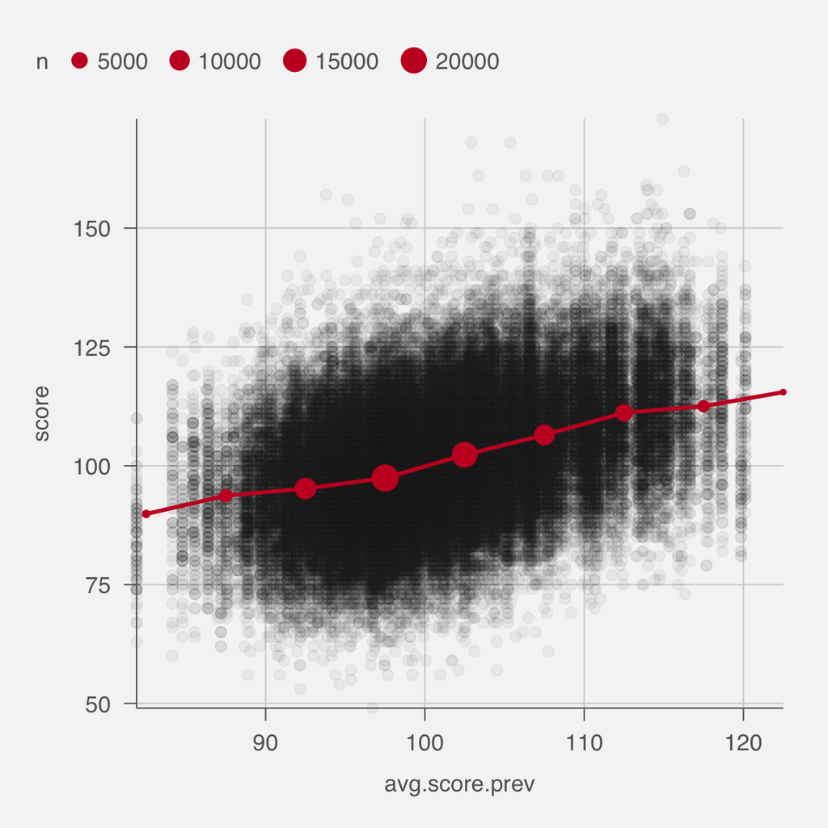

```r
g = ggplot(dd,
           aes(x = avg.score.prev,
               y = score)) +
  geom_point(color = pubdarkgray,
             alpha = 0.05) +
  geom_point(data = bin.means,
             aes(x = mid,
                 y = mean.score,
                 size = n),
             color = pubred) +
  geom_line(data = bin.means,
            aes(x = mid,
                y = mean.score),
            color = pubred)

g %>%
  pub(type = 'scatter')
```

The relationship looks pretty linear, at least for the bins with larger sample sizes (larger dots).

Here’s an animation showing the distribution of score for a moving window of `avg.score.prev`.

```r
n.frames = length(seq(80, 116, by=4))

## lines
dl = data.frame(left  = seq(80  , 116  , length=n.frames),
                right = seq(80+5, 116+5, length=n.frames),
                frame = 1:n.frames) %>%
  mutate(mid = left/2 + right/2)

## Stack two data frames that we want to use
## to plot in two windows
## Give each one NAs so it doesn't show up in the other window
## This is super hack-y, but it avoids making separate animations and
## using magick to glue them together

dl1 = dl %>% mutate(window='Subsets of predictor',
                    end=121)
dl2 = dl %>%
  mutate(window='Distribution of score for the subset',
         left=NA,
         right=NA,
         mid=NA,
         end=NA)

dl = rbind(dl1, dl2) %>%
  mutate(window = relevel(factor(window),
                          'Subsets of predictor'))


## Gotta manually jitter,
## otherwise the jitter will be different in each frame
## Not necessary for linear regression but we'll keep it anyway

dd = dd %>%
  mutate(jitter.score = jitter(score, amount=0.25))

## data for histogram and highlighted points
ddh = NULL
for(j in  dl$frame){
  cat(j, '')
  left  = dl$left[j]
  right = dl$right[j]
  temp  = dd %>%
    mutate(inside = ifelse(avg.score.prev <= right &
                           avg.score.prev >= left,
                           TRUE, FALSE),
           frame = j)

  ddh = rbind(ddh, temp)
}

## mean of highlighted points
dm = ddh %>%
  filter(inside==TRUE) %>%
  group_by(frame) %>%
  summarise(mean = mean(score),
            var = var(score),
            n = n()) %>%
  as.data.frame()


dl = dl %>% left_join(dm, by='frame')
dl = dl %>%
  mutate(mean.hist = ifelse(window=='Subsets of predictor', NA  , mean),
         mean      = ifelse(window=='Subsets of predictor', mean, NA  ))

ddh2 = ddh %>%
  mutate(hist.score = ifelse(inside==TRUE, score, NA),
         avg.score.prev = NA,
         window = 'Distribution of score for the subset')

ddh$hist.score = NA
ddh$window = 'Subsets of predictor'
ddh = rbind(ddh, ddh2)
ddh = ddh %>%
  mutate(window = relevel(factor(window),
                          'Subsets of predictor'))
#ddh = ddh %>% filter(frame %in% c(1,23))

## sample of data
samp = sample(unique(ddh$avg.score.prev), 100)
title = 'Distribution of Team Goals for Different Subsets'
g = ggplot(ddh %>%
             filter(frame %in% c(1:n.frames),
                    (avg.score.prev %in% samp |
                     is.na(avg.score.prev))),
       aes(x=avg.score.prev,
           y=jitter.score,
           color=inside,
           group=gid))+
  geom_point(alpha=0.3,
             show.legend = F)+
  scale_color_manual(values = c(publightgray,
                                pubred))+
  geom_vline(data=dl %>%
               filter(frame %in% c(1:n.frames)),
             aes(xintercept=left),
             color=pubdarkgray)+
  geom_vline(data=dl %>%
               filter(frame %in% c(1:n.frames)),
             aes(xintercept=right),
             color=pubdarkgray)+
  geom_point(data = dl %>%
               filter(window=='Subsets of predictor'),
             aes(x=mid,
                 y=mean),
             color=pubdarkgray,
             size=2,
            inherit.aes = F)+
  geom_segment(data = dl,
               aes(x=mid , xend=end,
                   y=mean, yend=mean),
               color = pubdarkgray,
               inherit.aes = F,
               linewidth=1)+
  geom_histogram(aes(x = after_stat(density),
                     y = hist.score),
                 fill=pubred,
                 color=pubbackgray,
                 binwidth=5,
                 inherit.aes = FALSE)+
  geom_hline(data=dl,
             aes(yintercept=mean.hist),
             color=pubdarkgray,
             linewidth=1)+
  facet_wrap(~window, scales='free_x')+
  scale_x_continuous(oob = squish,
                     expand = c(0,0))+
  scale_y_continuous(limits = c(40,180),
                     breaks = c(40, 110, 180),
                     oob = squish,
                     expand = c(0,0))+
  labs(title    = title,
       x = 'Predictor                                                         Proportion',
       y = 'Score')+
  theme_pub(type='hist', base_size=36/3, facet=T)

gg = g +
  transition_states(frame,
                    transition_length = 1,
                    state_length = 0,
                    wrap=F)

a = animate(gg,
            fps=10,
            nframes = 2*n.frames + 10,
            height=320,
            width=480,
            end_pause=10)
a

anim_save(a, filename = 'img/dist.of.score.for.different.subsets.nba.gif')
```

[figure not shown]

## A simple linear regression for NBA game outcomes

```r
lm1 = lm(score ~ avg.score.prev, data=dd)
summary(lm1)
```

```
##
## Call:
## lm(formula = score ~ avg.score.prev, data = dd)
##
## Residuals:
##     Min      1Q  Median      3Q     Max
## -48.749  -8.247  -0.290   7.961  65.268
##
## Coefficients:
##                 Estimate Std. Error t value Pr(>|t|)
## (Intercept)    20.115745   0.677197    29.7   <2e-16 ***
## avg.score.prev  0.802665   0.006705   119.7   <2e-16 ***
## ---
## Signif. codes:  0 '***' 0.001 '**' 0.01 '*' 0.05 '.' 0.1 ' ' 1
##
## Residual standard error: 12.1 on 73550 degrees of freedom
## Multiple R-squared:  0.1631, Adjusted R-squared:  0.1631
## F-statistic: 1.433e+04 on 1 and 73550 DF,  p-value: < 2.2e-16
```

## Prediction

```r
dd$yhat = predict(lm1, newdata = dd)
head(dd %>% select(score, opp.score, avg.score.prev, yhat))
```

```
##   score opp.score avg.score.prev     yhat
## 1    89        90       106.7317 105.7856
## 2    90        89       114.2073 111.7860
## 3   162       158       116.2683 113.4403
## 4   158       162       114.5976 112.0992
## 5   134       130       108.2805 107.0288
## 6   130       134       100.3902 100.6955
```

```r
temp = data.frame(avg.score.prev = 100)
predict(lm1, newdata = temp)
```

```
##        1
## 100.3823
```

```r
predict(lm1, newdata = temp, interval = 'confidence', level = 0.95)
```

```
##        fit      lwr      upr
## 1 100.3823 100.2942 100.4703
```

```r
predict(lm1, newdata = temp, interval = 'prediction', level = 0.95)
```

```
##        fit      lwr      upr
## 1 100.3823 76.66547 124.0991
```

## Confidence interval

```r
dd$yhat.lower = predict(lm1,
                        newdata = dd,
                        interval = 'confidence',
                        level = 0.95)[,'lwr']

dd$yhat.upper = predict(lm1,
                        newdata = dd,
                        interval = 'confidence',
                        level = 0.95)[,'upr']

dd %>%
  select(score, opp.score, avg.score.prev,
         yhat, yhat.lower, yhat.upper) %>%
  head()
```

```
##   score opp.score avg.score.prev     yhat yhat.lower yhat.upper
## 1    89        90       106.7317 105.7856   105.6683   105.9029
## 2    90        89       114.2073 111.7860   111.5890   111.9830
## 3   162       158       116.2683 113.4403   113.2187   113.6618
## 4   158       162       114.5976 112.0992   111.8977   112.3008
## 5   134       130       108.2805 107.0288   106.8970   107.1605
## 6   130       134       100.3902 100.6955   100.6079   100.7831
```

## Prediction interval

```r
dd$y.lower = predict(lm1,
                        newdata = dd,
                        interval = 'prediction',
                        level = 0.95)[,'lwr']

dd$y.upper = predict(lm1,
                        newdata = dd,
                        interval = 'prediction',
                        level = 0.95)[,'upr']

dd %>%
  select(team, score, opp.score, avg.score.prev,
         yhat, yhat.lower, yhat.upper,
         y.lower, y.upper) %>%
  head()
```

```
##   team score opp.score avg.score.prev     yhat yhat.lower yhat.upper  y.lower
## 1  HOU    89        90       106.7317 105.7856   105.6683   105.9029 82.06865
## 2  POR    90        89       114.2073 111.7860   111.5890   111.9830 88.06853
## 3  GOS   162       158       116.2683 113.4403   113.2187   113.6618 89.72259
## 4  DEN   158       162       114.5976 112.0992   111.8977   112.3008 88.38173
## 5  NYK   134       130       108.2805 107.0288   106.8970   107.1605 83.31173
## 6  CHH   130       134       100.3902 100.6955   100.6079   100.7831 76.97870
##    y.upper
## 1 129.5025
## 2 135.5035
## 3 137.1580
## 4 135.8168
## 5 130.7458
## 6 124.4123
```

## Multiple linear regression

First let’s prep the data.

```r
## Days rest
dd = dd %>%
  arrange(date) %>%
  group_by(team, season) %>%
  mutate(days.rest = c(NA, diff(date)))

head(dd)
```

```
## # A tibble: 6 × 17
## # Groups:   team, season [6]
##   date       team  score opp   opp.score season ha    gid      avg.score.prev
##   <date>     <chr> <dbl> <chr>     <dbl> <chr>  <chr> <chr>             <dbl>
## 1 1990-11-02 HOU      89 POR          90 1991   away  29000001           107.
## 2 1990-11-02 POR      90 HOU          89 1991   home  29000001           114.
## 3 1990-11-02 GOS     162 DEN         158 1991   away  29000002           116.
## 4 1990-11-02 DEN     158 GOS         162 1991   home  29000002           115.
## 5 1990-11-02 NYK     134 CHH         130 1991   away  29000003           108.
## 6 1990-11-02 CHH     130 NYK         134 1991   home  29000003           100.
## # ℹ 8 more variables: avg.score.prev.adj <dbl>, bin <fct>, yhat <dbl>,
## #   yhat.lower <dbl>, yhat.upper <dbl>, y.lower <dbl>, y.upper <dbl>,
## #   days.rest <dbl>
```

```r
tail(dd)
```

```
## # A tibble: 6 × 17
## # Groups:   team, season [6]
##   date       team  score opp   opp.score season ha    gid      avg.score.prev
##   <date>     <chr> <dbl> <chr>     <dbl> <chr>  <chr> <chr>             <dbl>
## 1 2022-04-10 DET     106 PHI         118 2022   away  22101228           107.
## 2 2022-04-10 PHI     118 DET         106 2022   home  22101228           114.
## 3 2022-04-10 SAC     116 PHX         109 2022   away  22101229           114.
## 4 2022-04-10 PHX     109 SAC         116 2022   home  22101229           115.
## 5 2022-04-10 UTA     111 POR          80 2022   away  22101230           116.
## 6 2022-04-10 POR      80 UTA         111 2022   home  22101230           116.
## # ℹ 8 more variables: avg.score.prev.adj <dbl>, bin <fct>, yhat <dbl>,
## #   yhat.lower <dbl>, yhat.upper <dbl>, y.lower <dbl>, y.upper <dbl>,
## #   days.rest <dbl>
```

```r
dd %>% filter(team=='PHI')
```

```
## # A tibble: 1,983 × 17
## # Groups:   team, season [25]
##    date       team  score opp   opp.score season ha    gid      avg.score.prev
##    <date>     <chr> <dbl> <chr>     <dbl> <chr>  <chr> <chr>             <dbl>
##  1 1997-10-31 PHI      88 MIL         103 1998   home  29700003           100.
##  2 1997-11-01 PHI      74 CHI          94 1998   away  29700018           100.
##  3 1997-11-05 PHI      88 ATL          93 1998   home  29700045           100.
##  4 1997-11-06 PHI      93 MIL         100 1998   away  29700052           100.
##  5 1997-11-09 PHI     105 SEA         112 1998   home  29700075           100.
##  6 1997-11-12 PHI     114 HOU         100 1998   away  29700093           100.
##  7 1997-11-13 PHI      99 DAL          98 1998   away  29700099           100.
##  8 1997-11-15 PHI     101 BOS         107 1998   home  29700112           100.
##  9 1997-11-19 PHI      97 WAS          86 1998   home  29700139           100.
## 10 1997-11-22 PHI      94 ORL         108 1998   home  29700161           100.
## # ℹ 1,973 more rows
## # ℹ 8 more variables: avg.score.prev.adj <dbl>, bin <fct>, yhat <dbl>,
## #   yhat.lower <dbl>, yhat.upper <dbl>, y.lower <dbl>, y.upper <dbl>,
## #   days.rest <dbl>
```

```r
table(dd$days.rest)
```

```
##
##     1     2     3     4     5     6     7     8     9    10    11    12    13
## 17302 39935 11078  2715   675   486   168   126   106    12     3     1     1
##   142   143   144   145   146
##     3    13     3     2     1
```

Let’s treat NA (first game of the season), as 4 or more.

```r
dd = dd %>%
  mutate(days.rest = ifelse(is.na(days.rest), 4, days.rest))
head(dd)
```

```
## # A tibble: 6 × 17
## # Groups:   team, season [6]
##   date       team  score opp   opp.score season ha    gid      avg.score.prev
##   <date>     <chr> <dbl> <chr>     <dbl> <chr>  <chr> <chr>             <dbl>
## 1 1990-11-02 HOU      89 POR          90 1991   away  29000001           107.
## 2 1990-11-02 POR      90 HOU          89 1991   home  29000001           114.
## 3 1990-11-02 GOS     162 DEN         158 1991   away  29000002           116.
## 4 1990-11-02 DEN     158 GOS         162 1991   home  29000002           115.
## 5 1990-11-02 NYK     134 CHH         130 1991   away  29000003           108.
## 6 1990-11-02 CHH     130 NYK         134 1991   home  29000003           100.
## # ℹ 8 more variables: avg.score.prev.adj <dbl>, bin <fct>, yhat <dbl>,
## #   yhat.lower <dbl>, yhat.upper <dbl>, y.lower <dbl>, y.upper <dbl>,
## #   days.rest <dbl>
```

Create rest differential `rest.diff` by grouping by `gid` and finding the difference in `days.rest` between the home and away team.

```r
dd$days.rest = gsub('4 or more', 4, dd$days.rest)
dd$days.rest = as.numeric(dd$days.rest)

dd = dd %>%
  group_by(gid) %>%
  mutate(rest.diff = ifelse(ha=='home', diff(days.rest), -diff(days.rest))) %>%
  ungroup()

head(dd)
```

```
## # A tibble: 6 × 18
##   date       team  score opp   opp.score season ha    gid      avg.score.prev
##   <date>     <chr> <dbl> <chr>     <dbl> <chr>  <chr> <chr>             <dbl>
## 1 1990-11-02 HOU      89 POR          90 1991   away  29000001           107.
## 2 1990-11-02 POR      90 HOU          89 1991   home  29000001           114.
## 3 1990-11-02 GOS     162 DEN         158 1991   away  29000002           116.
## 4 1990-11-02 DEN     158 GOS         162 1991   home  29000002           115.
## 5 1990-11-02 NYK     134 CHH         130 1991   away  29000003           108.
## 6 1990-11-02 CHH     130 NYK         134 1991   home  29000003           100.
## # ℹ 9 more variables: avg.score.prev.adj <dbl>, bin <fct>, yhat <dbl>,
## #   yhat.lower <dbl>, yhat.upper <dbl>, y.lower <dbl>, y.upper <dbl>,
## #   days.rest <dbl>, rest.diff <dbl>
```

```r
tail(dd)
```

```
## # A tibble: 6 × 18
##   date       team  score opp   opp.score season ha    gid      avg.score.prev
##   <date>     <chr> <dbl> <chr>     <dbl> <chr>  <chr> <chr>             <dbl>
## 1 2022-04-10 DET     106 PHI         118 2022   away  22101228           107.
## 2 2022-04-10 PHI     118 DET         106 2022   home  22101228           114.
## 3 2022-04-10 SAC     116 PHX         109 2022   away  22101229           114.
## 4 2022-04-10 PHX     109 SAC         116 2022   home  22101229           115.
## 5 2022-04-10 UTA     111 POR          80 2022   away  22101230           116.
## 6 2022-04-10 POR      80 UTA         111 2022   home  22101230           116.
## # ℹ 9 more variables: avg.score.prev.adj <dbl>, bin <fct>, yhat <dbl>,
## #   yhat.lower <dbl>, yhat.upper <dbl>, y.lower <dbl>, y.upper <dbl>,
## #   days.rest <dbl>, rest.diff <dbl>
```

Let’s see how many games have each value of `days.rest` and `rest.diff`.

```r
table(dd$days.rest)
```

```
##
##     1     2     3     4     5     6     7     8     9    10    11    12    13
## 17302 39935 11078  3637   675   486   168   126   106    12     3     1     1
##   142   143   144   145   146
##     3    13     3     2     1
```

```r
table(dd$rest.diff)
```

```
##
##  -144  -143   -11    -9    -8    -7    -6    -5    -4    -3    -2    -1     0
##     1     1     2     2    16    14    72    75   193  1100  3569 13688 34978
##     1     2     3     4     5     6     7     8     9    11   143   144
## 13688  3569  1100   193    75    72    14    16     2     2     1     1
```

Let’s group higher values into a 4 or more category. We don’t mind this being categorical because it’s not clear that there is a linear relationship between days.rest and score. We’ll do the same for rest.diff.

```r
dd = dd %>%
  mutate(days.rest = ifelse(days.rest >= 4 | is.na(days.rest),
                            '4 or more',
                            days.rest),
         rest.diff = case_when(rest.diff >=  3 ~  '3 or more',
                               rest.diff <= -3 ~ '-3 or fewer',
                               TRUE ~ as.character(rest.diff)))

## check
head(dd,2)
```

```
## # A tibble: 2 × 18
##   date       team  score opp   opp.score season ha    gid      avg.score.prev
##   <date>     <chr> <dbl> <chr>     <dbl> <chr>  <chr> <chr>             <dbl>
## 1 1990-11-02 HOU      89 POR          90 1991   away  29000001           107.
## 2 1990-11-02 POR      90 HOU          89 1991   home  29000001           114.
## # ℹ 9 more variables: avg.score.prev.adj <dbl>, bin <fct>, yhat <dbl>,
## #   yhat.lower <dbl>, yhat.upper <dbl>, y.lower <dbl>, y.upper <dbl>,
## #   days.rest <chr>, rest.diff <chr>
```

```r
tail(dd,2)
```

```
## # A tibble: 2 × 18
##   date       team  score opp   opp.score season ha    gid      avg.score.prev
##   <date>     <chr> <dbl> <chr>     <dbl> <chr>  <chr> <chr>             <dbl>
## 1 2022-04-10 UTA     111 POR          80 2022   away  22101230           116.
## 2 2022-04-10 POR      80 UTA         111 2022   home  22101230           116.
## # ℹ 9 more variables: avg.score.prev.adj <dbl>, bin <fct>, yhat <dbl>,
## #   yhat.lower <dbl>, yhat.upper <dbl>, y.lower <dbl>, y.upper <dbl>,
## #   days.rest <chr>, rest.diff <chr>
```

```r
table(dd$days.rest)
```

```
##
##         1         2         3 4 or more
##     17302     39935     11078      5237
```

```r
table(dd$rest.diff)
```

```
##
##          -1          -2 -3 or fewer           0           1           2
##       13688        3569        1476       34978       13688        3569
##   3 or more
##        1476
```

Let’s also add distance traveled before this game.

```r
## Distance between every pair of cities.
dm = read.csv('data/distance.matrix.nba.csv')
colnames(dm)[1] = 'prev.loc'
head(dm)
```

```
##   prev.loc ATL BKN BOS CHA CHI CLE  DAL  DEN DET  GSW  HOU IND  LAC  LAL  MEM
## 1      ATL   0 746 936 227 589 555  720 1210 621 2123  701 426 1933 1933  336
## 2      BKN 746   0 190 531 715 405 1372 1630 498 2557 1418 645 2449 2449  954
## 3      BOS 936 190   0 721 851 549 1549 1766 620 2682 1604 805 2592 2592 1135
## 4      CHA 227 531 721   0 589 436  929 1357 532 2286  926 428 2117 2117  520
## 5      CHI 589 715 851 589   0 310  803  917 233 1842  941 166 1742 1742  483
## 6      CLE 555 405 549 436 310   0 1025 1225 115 2152 1115 263 2047 2047  631
##    MIA MIL  MIN  NOP NYK  OKC  ORL PHI  PHX  POR  SAS  SAC TOR  UTA WAS
## 1  606 669  908  420 748  755  402 663 1588 2168  878 2083 734 1580 543
## 2 1090 735 1019 1164   5 1326  938  83 2141 2441 1579 2501 344 1970 203
## 3 1257 856 1121 1354 188 1493 1116 273 2295 2532 1762 2624 429 2094 394
## 4  654 659  939  645 533  939  463 448 1779 2285 1101 2241 587 1724 330
## 5 1191  81  353  829 713  691  987 667 1450 1752 1050 1787 438 1255 597
## 6 1089 336  630  919 404  950  895 359 1746 2049 1254 2096 189 1565 305
```

```r
dm = dm %>%
  pivot_longer(cols = - prev.loc,
               names_to = 'loc',
               values_to = 'miles')
head(dm)
```

```
## # A tibble: 6 × 3
##   prev.loc loc   miles
##   <chr>    <chr> <int>
## 1 ATL      ATL       0
## 2 ATL      BKN     746
## 3 ATL      BOS     936
## 4 ATL      CHA     227
## 5 ATL      CHI     589
## 6 ATL      CLE     555
```

Let’s add these distances to our data frame. We need the location of the current game, as well as the location of the previous game `prev.loc`. Once we have `loc` and `prev.loc`, we can join the distances to this data frame. We can group by game and compute `miles.diff` like we did `rest.diff` above.

```r
dd = dd %>%
  group_by(team, season) %>%
  mutate(loc = ifelse(ha=='home', team, opp),
         prev.loc = lag(loc),
         prev.loc = ifelse(is.na(prev.loc), team, prev.loc)) %>%
  left_join(dm, by=c('loc', 'prev.loc')) %>%
  group_by(gid) %>%
  mutate(miles.diff = ifelse(ha=='home', diff(miles), -diff(miles)))

## check
head(dd)
```

```
## # A tibble: 6 × 22
## # Groups:   gid [3]
##   date       team  score opp   opp.score season ha    gid      avg.score.prev
##   <date>     <chr> <dbl> <chr>     <dbl> <chr>  <chr> <chr>             <dbl>
## 1 1990-11-02 HOU      89 POR          90 1991   away  29000001           107.
## 2 1990-11-02 POR      90 HOU          89 1991   home  29000001           114.
## 3 1990-11-02 GOS     162 DEN         158 1991   away  29000002           116.
## 4 1990-11-02 DEN     158 GOS         162 1991   home  29000002           115.
## 5 1990-11-02 NYK     134 CHH         130 1991   away  29000003           108.
## 6 1990-11-02 CHH     130 NYK         134 1991   home  29000003           100.
## # ℹ 13 more variables: avg.score.prev.adj <dbl>, bin <fct>, yhat <dbl>,
## #   yhat.lower <dbl>, yhat.upper <dbl>, y.lower <dbl>, y.upper <dbl>,
## #   days.rest <chr>, rest.diff <chr>, loc <chr>, prev.loc <chr>, miles <int>,
## #   miles.diff <int>
```

```r
tail(dd)
```

```
## # A tibble: 6 × 22
## # Groups:   gid [3]
##   date       team  score opp   opp.score season ha    gid      avg.score.prev
##   <date>     <chr> <dbl> <chr>     <dbl> <chr>  <chr> <chr>             <dbl>
## 1 2022-04-10 DET     106 PHI         118 2022   away  22101228           107.
## 2 2022-04-10 PHI     118 DET         106 2022   home  22101228           114.
## 3 2022-04-10 SAC     116 PHX         109 2022   away  22101229           114.
## 4 2022-04-10 PHX     109 SAC         116 2022   home  22101229           115.
## 5 2022-04-10 UTA     111 POR          80 2022   away  22101230           116.
## 6 2022-04-10 POR      80 UTA         111 2022   home  22101230           116.
## # ℹ 13 more variables: avg.score.prev.adj <dbl>, bin <fct>, yhat <dbl>,
## #   yhat.lower <dbl>, yhat.upper <dbl>, y.lower <dbl>, y.upper <dbl>,
## #   days.rest <chr>, rest.diff <chr>, loc <chr>, prev.loc <chr>, miles <int>,
## #   miles.diff <int>
```

```r
dd %>% filter(team=='PHI')
```

```
## # A tibble: 1,983 × 22
## # Groups:   gid [1,983]
##    date       team  score opp   opp.score season ha    gid      avg.score.prev
##    <date>     <chr> <dbl> <chr>     <dbl> <chr>  <chr> <chr>             <dbl>
##  1 1997-10-31 PHI      88 MIL         103 1998   home  29700003           100.
##  2 1997-11-01 PHI      74 CHI          94 1998   away  29700018           100.
##  3 1997-11-05 PHI      88 ATL          93 1998   home  29700045           100.
##  4 1997-11-06 PHI      93 MIL         100 1998   away  29700052           100.
##  5 1997-11-09 PHI     105 SEA         112 1998   home  29700075           100.
##  6 1997-11-12 PHI     114 HOU         100 1998   away  29700093           100.
##  7 1997-11-13 PHI      99 DAL          98 1998   away  29700099           100.
##  8 1997-11-15 PHI     101 BOS         107 1998   home  29700112           100.
##  9 1997-11-19 PHI      97 WAS          86 1998   home  29700139           100.
## 10 1997-11-22 PHI      94 ORL         108 1998   home  29700161           100.
## # ℹ 1,973 more rows
## # ℹ 13 more variables: avg.score.prev.adj <dbl>, bin <fct>, yhat <dbl>,
## #   yhat.lower <dbl>, yhat.upper <dbl>, y.lower <dbl>, y.upper <dbl>,
## #   days.rest <chr>, rest.diff <chr>, loc <chr>, prev.loc <chr>, miles <int>,
## #   miles.diff <int>
```

Let’s see if there is a relationship between `miles.diff` and `score`.

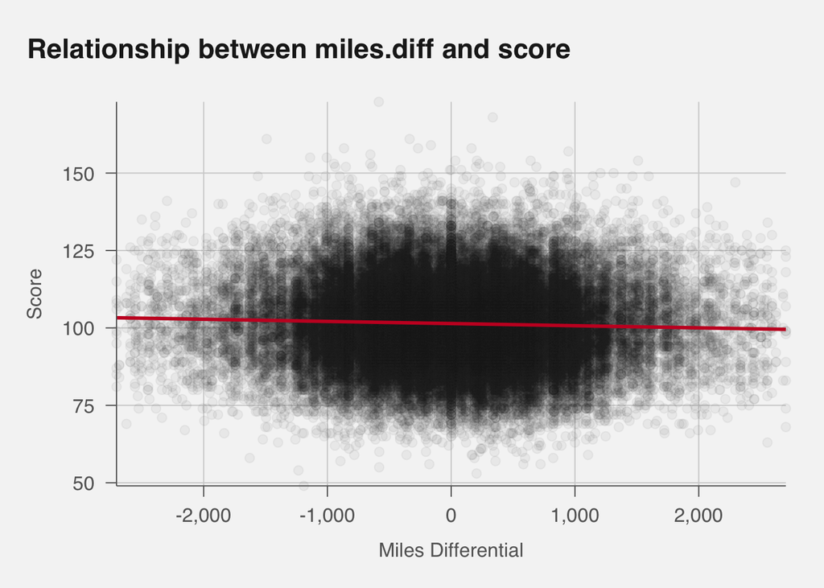

```r
g = ggplot(dd,
       aes(x = miles.diff,
           y = score))+
  geom_point(alpha=0.05,
             color=pubdarkgray)+
  geom_smooth(method='lm',
              color=pubred)+
  labs(title='Relationship between miles.diff and score',
       x='Miles Differential',
       y='Score')

g %>%
  pub(type='scatter')
```

Maybe a slightly negative relationship, but we might not expect a significant coefficient when we include this in a multiple regression model.

## Modeling

```r
dm = dd %>%
  filter(season == 2022)
lm1 = lm(score ~ ha                         , data=dm); summary(lm1)
```

```
##
## Call:
## lm(formula = score ~ ha, data = dm)
##
## Residuals:
##     Min      1Q  Median      3Q     Max
## -34.754  -8.477  -0.477   8.246  48.246
##
## Coefficients:
##             Estimate Std. Error t value Pr(>|t|)
## (Intercept) 109.7545     0.3591 305.652  < 2e-16 ***
## hahome        1.7228     0.5078   3.392 0.000704 ***
## ---
## Signif. codes:  0 '***' 0.001 '**' 0.01 '*' 0.05 '.' 0.1 ' ' 1
##
## Residual standard error: 12.59 on 2458 degrees of freedom
## Multiple R-squared:  0.00466,    Adjusted R-squared:  0.004255
## F-statistic: 11.51 on 1 and 2458 DF,  p-value: 0.0007036
```

```r
lm2 = lm(score ~ ha + miles.diff            , data=dm); summary(lm2)
```

```
##
## Call:
## lm(formula = score ~ ha + miles.diff, data = dm)
##
## Residuals:
##     Min      1Q  Median      3Q     Max
## -34.796  -8.510  -0.377   8.268  48.173
##
## Coefficients:
##               Estimate Std. Error t value Pr(>|t|)
## (Intercept)  1.098e+02  3.811e-01 288.086  < 2e-16 ***
## hahome       1.640e+00  5.684e-01   2.885  0.00395 **
## miles.diff  -1.149e-04  3.523e-04  -0.326  0.74438
## ---
## Signif. codes:  0 '***' 0.001 '**' 0.01 '*' 0.05 '.' 0.1 ' ' 1
##
## Residual standard error: 12.6 on 2457 degrees of freedom
## Multiple R-squared:  0.004703,   Adjusted R-squared:  0.003893
## F-statistic: 5.806 on 2 and 2457 DF,  p-value: 0.003052
```

```r
lm3 = lm(score ~ ha + rest.diff             , data=dm); summary(lm3)
```

```
##
## Call:
## lm(formula = score ~ ha + rest.diff, data = dm)
##
## Residuals:
##     Min      1Q  Median      3Q     Max
## -34.738  -8.254  -0.254   8.262  48.799
##
## Coefficients:
##                      Estimate Std. Error t value Pr(>|t|)
## (Intercept)          109.2014     0.6202 176.067  < 2e-16 ***
## hahome                 1.6267     0.5105   3.186  0.00146 **
## rest.diff-2            0.1244     1.3038   0.095  0.92400
## rest.diff-3 or fewer   4.6985     2.6325   1.785  0.07442 .
## rest.diff0             0.4257     0.6826   0.624  0.53295
## rest.diff1             0.5366     0.8252   0.650  0.51558
## rest.diff2             3.6046     1.3071   2.758  0.00586 **
## rest.diff3 or more     6.3552     2.6307   2.416  0.01577 *
## ---
## Signif. codes:  0 '***' 0.001 '**' 0.01 '*' 0.05 '.' 0.1 ' ' 1
##
## Residual standard error: 12.57 on 2452 degrees of freedom
## Multiple R-squared:  0.01098,    Adjusted R-squared:  0.008154
## F-statistic: 3.888 on 7 and 2452 DF,  p-value: 0.0003208
```

```r
lm4 = lm(score ~ ha + rest.diff + team      , data=dm); summary(lm4)
```

```
##
## Call:
## lm(formula = score ~ ha + rest.diff + team, data = dm)
##
## Residuals:
##     Min      1Q  Median      3Q     Max
## -34.999  -8.302  -0.154   7.839  45.437
##
## Coefficients:
##                      Estimate Std. Error t value Pr(>|t|)
## (Intercept)          112.8230     1.4526  77.667  < 2e-16 ***
## hahome                 1.6269     0.4945   3.290  0.00102 **
## rest.diff-2           -0.9588     1.2710  -0.754  0.45068
## rest.diff-3 or fewer   4.3920     2.5614   1.715  0.08653 .
## rest.diff0             0.3246     0.6660   0.487  0.62601
## rest.diff1             0.1866     0.8041   0.232  0.81650
## rest.diff2             3.3956     1.2694   2.675  0.00752 **
## rest.diff3 or more     5.7953     2.5643   2.260  0.02391 *
## teamBKN               -1.1021     1.9019  -0.579  0.56234
## teamBOS               -2.2673     1.9024  -1.192  0.23346
## teamCHA                1.2712     1.9020   0.668  0.50398
## teamCHI               -2.4505     1.9025  -1.288  0.19785
## teamCLE               -6.2733     1.9025  -3.297  0.00099 ***
## teamDAL               -6.0765     1.9031  -3.193  0.00143 **
## teamDEN               -1.3252     1.9039  -0.696  0.48646
## teamDET               -9.2087     1.9024  -4.840 1.38e-06 ***
## teamGSW               -3.1175     1.9042  -1.637  0.10173
## teamHOU               -4.3067     1.9024  -2.264  0.02367 *
## teamIND               -2.7590     1.9049  -1.448  0.14764
## teamLAC               -5.5845     1.9020  -2.936  0.00335 **
## teamLAL               -1.9874     1.9033  -1.044  0.29652
## teamMEM                1.6613     1.9024   0.873  0.38261
## teamMIA               -3.9862     1.9024  -2.095  0.03625 *
## teamMIL                1.4308     1.9027   0.752  0.45213
## teamMIN                1.9123     1.9021   1.005  0.31483
## teamNOP               -4.8038     1.9036  -2.524  0.01168 *
## teamNYK               -7.5496     1.9030  -3.967 7.49e-05 ***
## teamOKC              -10.3100     1.9027  -5.419 6.60e-08 ***
## teamORL               -9.7145     1.9019  -5.108 3.51e-07 ***
## teamPHI               -4.1822     1.9034  -2.197  0.02809 *
## teamPHX                0.8095     1.9027   0.425  0.67056
## teamPOR               -7.8963     1.9028  -4.150 3.44e-05 ***
## teamSAC               -3.7270     1.9024  -1.959  0.05021 .
## teamSAS               -0.8471     1.9020  -0.445  0.65609
## teamTOR               -4.6129     1.9033  -2.424  0.01544 *
## teamUTA               -0.5337     1.9036  -0.280  0.77923
## teamWAS               -5.5009     1.9033  -2.890  0.00388 **
## ---
## Signif. codes:  0 '***' 0.001 '**' 0.01 '*' 0.05 '.' 0.1 ' ' 1
##
## Residual standard error: 12.17 on 2423 degrees of freedom
## Multiple R-squared:  0.08306,    Adjusted R-squared:  0.06944
## F-statistic: 6.097 on 36 and 2423 DF,  p-value: < 2.2e-16
```

```r
lm5 = lm(score ~ ha + rest.diff + team + opp, data=dm); summary(lm5)
```

```
##
## Call:
## lm(formula = score ~ ha + rest.diff + team + opp, data = dm)
##
## Residuals:
##     Min      1Q  Median      3Q     Max
## -39.440  -7.934   0.175   7.709  43.861
##
## Coefficients:
##                      Estimate Std. Error t value Pr(>|t|)
## (Intercept)          115.2329     1.9108  60.305  < 2e-16 ***
## hahome                 1.6287     0.4736   3.439 0.000593 ***
## rest.diff-2           -0.9719     1.2236  -0.794 0.427091
## rest.diff-3 or fewer   4.1317     2.4681   1.674 0.094259 .
## rest.diff0             0.2746     0.6414   0.428 0.668556
## rest.diff1             0.3267     0.7742   0.422 0.673052
## rest.diff2             2.9451     1.2221   2.410 0.016032 *
## rest.diff3 or more     5.6380     2.4649   2.287 0.022266 *
## teamBKN               -0.9982     1.8230  -0.548 0.584026
## teamBOS               -2.7519     1.8245  -1.508 0.131619
## teamCHA                1.4124     1.8238   0.774 0.438749
## teamCHI               -2.4824     1.8244  -1.361 0.173759
## teamCLE               -6.7992     1.8246  -3.726 0.000199 ***
## teamDAL               -6.7144     1.8294  -3.670 0.000248 ***
## teamDEN               -1.7360     1.8301  -0.949 0.342947
## teamDET               -9.2525     1.8234  -5.074 4.19e-07 ***
## teamGSW               -3.6475     1.8303  -1.993 0.046388 *
## teamHOU               -4.4030     1.8286  -2.408 0.016123 *
## teamIND               -2.7356     1.8269  -1.497 0.134417
## teamLAC               -6.0151     1.8282  -3.290 0.001016 **
## teamLAL               -2.3158     1.8297  -1.266 0.205758
## teamMEM                1.1985     1.8286   0.655 0.512273
## teamMIA               -4.5000     1.8245  -2.466 0.013717 *
## teamMIL                1.3509     1.8235   0.741 0.458877
## teamMIN                1.7996     1.8284   0.984 0.325091
## teamNOP               -5.1989     1.8298  -2.841 0.004532 **
## teamNYK               -7.9661     1.8249  -4.365 1.32e-05 ***
## teamOKC              -10.7959     1.8290  -5.903 4.08e-09 ***
## teamORL               -9.9024     1.8240  -5.429 6.24e-08 ***
## teamPHI               -4.3199     1.8241  -2.368 0.017954 *
```

[output cut: 27 more lines]

```
## oppORL                -0.5981     1.8240  -0.328 0.743015
## oppPHI                -5.1324     1.8241  -2.814 0.004938 **
## oppPHX                -5.2807     1.8290  -2.887 0.003921 **
## oppPOR                 2.0157     1.8289   1.102 0.270512
## oppSAC                 3.2014     1.8285   1.751 0.080109 .
## oppSAS                 0.3026     1.8281   0.166 0.868526
## oppTOR                -5.5962     1.8251  -3.066 0.002192 **
## oppUTA                -5.1655     1.8297  -2.823 0.004795 **
## oppWAS                -0.8068     1.8252  -0.442 0.658514
## ---
## Signif. codes:  0 '***' 0.001 '**' 0.01 '*' 0.05 '.' 0.1 ' ' 1
##
## Residual standard error: 11.66 on 2394 degrees of freedom
## Multiple R-squared:  0.1693, Adjusted R-squared:  0.1467
## F-statistic: 7.504 on 65 and 2394 DF,  p-value: < 2.2e-16
```

```r
lm6 = lm(score ~ ha + rest.diff + team + opp + avg.score.prev, data=dm); summary(lm6)
```

```
##
## Call:
## lm(formula = score ~ ha + rest.diff + team + opp + avg.score.prev,
##     data = dm)
##
## Residuals:
##     Min      1Q  Median      3Q     Max
## -39.440  -7.934   0.175   7.709  43.861
##
## Coefficients: (1 not defined because of singularities)
##                      Estimate Std. Error t value Pr(>|t|)
## (Intercept)          115.2329     1.9108  60.305  < 2e-16 ***
## hahome                 1.6287     0.4736   3.439 0.000593 ***
## rest.diff-2           -0.9719     1.2236  -0.794 0.427091
## rest.diff-3 or fewer   4.1317     2.4681   1.674 0.094259 .
## rest.diff0             0.2746     0.6414   0.428 0.668556
## rest.diff1             0.3267     0.7742   0.422 0.673052
## rest.diff2             2.9451     1.2221   2.410 0.016032 *
## rest.diff3 or more     5.6380     2.4649   2.287 0.022266 *
## teamBKN               -0.9982     1.8230  -0.548 0.584026
## teamBOS               -2.7519     1.8245  -1.508 0.131619
## teamCHA                1.4124     1.8238   0.774 0.438749
## teamCHI               -2.4824     1.8244  -1.361 0.173759
## teamCLE               -6.7992     1.8246  -3.726 0.000199 ***
## teamDAL               -6.7144     1.8294  -3.670 0.000248 ***
## teamDEN               -1.7360     1.8301  -0.949 0.342947
## teamDET               -9.2525     1.8234  -5.074 4.19e-07 ***
## teamGSW               -3.6475     1.8303  -1.993 0.046388 *
## teamHOU               -4.4030     1.8286  -2.408 0.016123 *
## teamIND               -2.7356     1.8269  -1.497 0.134417
## teamLAC               -6.0151     1.8282  -3.290 0.001016 **
## teamLAL               -2.3158     1.8297  -1.266 0.205758
## teamMEM                1.1985     1.8286   0.655 0.512273
## teamMIA               -4.5000     1.8245  -2.466 0.013717 *
## teamMIL                1.3509     1.8235   0.741 0.458877
## teamMIN                1.7996     1.8284   0.984 0.325091
## teamNOP               -5.1989     1.8298  -2.841 0.004532 **
## teamNYK               -7.9661     1.8249  -4.365 1.32e-05 ***
## teamOKC              -10.7959     1.8290  -5.903 4.08e-09 ***
## teamORL               -9.9024     1.8240  -5.429 6.24e-08 ***
```

[output cut: 29 more lines]

```
## oppPHI                -5.1324     1.8241  -2.814 0.004938 **
## oppPHX                -5.2807     1.8290  -2.887 0.003921 **
## oppPOR                 2.0157     1.8289   1.102 0.270512
## oppSAC                 3.2014     1.8285   1.751 0.080109 .
## oppSAS                 0.3026     1.8281   0.166 0.868526
## oppTOR                -5.5962     1.8251  -3.066 0.002192 **
## oppUTA                -5.1655     1.8297  -2.823 0.004795 **
## oppWAS                -0.8068     1.8252  -0.442 0.658514
## avg.score.prev             NA         NA      NA       NA
## ---
## Signif. codes:  0 '***' 0.001 '**' 0.01 '*' 0.05 '.' 0.1 ' ' 1
##
## Residual standard error: 11.66 on 2394 degrees of freedom
## Multiple R-squared:  0.1693, Adjusted R-squared:  0.1467
## F-statistic: 7.504 on 65 and 2394 DF,  p-value: < 2.2e-16
```

Including `miles.diff` lowered Adj R^2, and was not significant, so we removed it. The `avg.score.prev` predictor was removed automatically by the `lm` function because of perfect collinearity. Other predictors increased Adj R^2, were significant, and had the expected signs, so we kept them in. The coefficient for -3 or fewer seems high but there were very few observations in that category. We could group that with -2 maybe. Other coefficients seem pretty reasonable.

Let’s -2 or fewer instead of -3 or fewer, use 2 or more instead of 3 or more, and set the reference level to “0”. Let’s also create a column for `rest.diff` that is numeric for comparison.

```r
dm = dm %>%
  mutate(rest.diff.num = gsub(' or.+', '', rest.diff),
         rest.diff.num = as.numeric(rest.diff.num),
         rest.diff = case_when(rest.diff %in% c('-2', '-3 or fewer') ~ '-2 or fewer',
                               rest.diff %in% c('2', '3 or more') ~ '2 or more',
                               TRUE ~ as.character(rest.diff)),
         rest.diff = factor(rest.diff,
                            levels = c('-2 or fewer', '-1', '0', '1', '2 or more')),
         rest.diff = relevel(rest.diff, '0'))
table(dm$rest.diff.num)
```

```
##
##   -3   -2   -1    0    1    2    3
##   24  116  468 1244  468  116   24
```

```r
table(dm$rest.diff)
```

```
##
##           0 -2 or fewer          -1           1   2 or more
##        1244         140         468         468         140
```

```r
lm7 = lm(score ~ ha + rest.diff     + team + opp, data=dm); summary(lm7)
```

```
##
## Call:
## lm(formula = score ~ ha + rest.diff + team + opp, data = dm)
##
## Residuals:
##     Min      1Q  Median      3Q     Max
## -39.606  -7.829   0.163   7.713  43.939
##
## Coefficients:
##                       Estimate Std. Error t value Pr(>|t|)
## (Intercept)          115.34665    1.87504  61.517  < 2e-16 ***
## hahome                 1.64735    0.47297   3.483 0.000505 ***
## rest.diff-2 or fewer  -0.36736    1.04826  -0.350 0.726035
## rest.diff-1           -0.27231    0.64173  -0.424 0.671362
## rest.diff1             0.05232    0.64173   0.082 0.935023
## rest.diff2 or more     3.13422    1.04826   2.990 0.002819 **
## teamBKN               -0.92009    1.82355  -0.505 0.613916
## teamBOS               -2.76504    1.82555  -1.515 0.129997
## teamCHA                1.39550    1.82472   0.765 0.444483
## teamCHI               -2.40703    1.82450  -1.319 0.187201
## teamCLE               -6.74348    1.82536  -3.694 0.000225 ***
## teamDAL               -6.61798    1.82987  -3.617 0.000305 ***
## teamDEN               -1.56265    1.82913  -0.854 0.393017
## teamDET               -9.19138    1.82413  -5.039 5.04e-07 ***
## teamGSW               -3.52712    1.83049  -1.927 0.054113 .
## teamHOU               -4.36738    1.82950  -2.387 0.017054 *
## teamIND               -2.53490    1.82485  -1.389 0.164933
## teamLAC               -6.02729    1.82914  -3.295 0.000998 ***
## teamLAL               -2.13150    1.82881  -1.166 0.243927
## teamMEM                1.28582    1.82920   0.703 0.482161
## teamMIA               -4.40776    1.82502  -2.415 0.015802 *
## teamMIL                1.38921    1.82375   0.762 0.446295
## teamMIN                1.83371    1.82924   1.002 0.316230
## teamNOP               -5.07495    1.82996  -2.773 0.005593 **
## teamNYK               -7.86913    1.82532  -4.311 1.69e-05 ***
## teamOKC              -10.66214    1.82877  -5.830 6.28e-09 ***
## teamORL               -9.86203    1.82499  -5.404 7.17e-08 ***
## teamPHI               -4.26734    1.82499  -2.338 0.019455 *
## teamPHX                0.27532    1.82932   0.151 0.880378
## teamPOR               -8.07404    1.82938  -4.414 1.06e-05 ***
```

[output cut: 25 more lines]

```
## oppORL                -0.56693    1.82499  -0.311 0.756095
## oppPHI                -5.08091    1.82499  -2.784 0.005410 **
## oppPHX                -5.23489    1.82932  -2.862 0.004251 **
## oppPOR                 2.09228    1.82938   1.144 0.252860
## oppSAC                 3.20045    1.82944   1.749 0.080348 .
## oppSAS                 0.37992    1.82881   0.208 0.835446
## oppTOR                -5.44005    1.82466  -2.981 0.002898 **
## oppUTA                -5.03770    1.82983  -2.753 0.005948 **
## oppWAS                -0.65331    1.82488  -0.358 0.720375
## ---
## Signif. codes:  0 '***' 0.001 '**' 0.01 '*' 0.05 '.' 0.1 ' ' 1
##
## Residual standard error: 11.66 on 2396 degrees of freedom
## Multiple R-squared:  0.1676, Adjusted R-squared:  0.1457
## F-statistic: 7.658 on 63 and 2396 DF,  p-value: < 2.2e-16
```

```r
lm8 = lm(score ~ ha + rest.diff.num + team + opp, data=dm); summary(lm8)
```

```
##
## Call:
## lm(formula = score ~ ha + rest.diff.num + team + opp, data = dm)
##
## Residuals:
##     Min      1Q  Median      3Q     Max
## -39.568  -7.857   0.246   7.721  43.652
##
## Coefficients:
##               Estimate Std. Error t value Pr(>|t|)
## (Intercept)   115.4522     1.8569  62.173  < 2e-16 ***
## hahome          1.6364     0.4725   3.464 0.000543 ***
## rest.diff.num   0.5108     0.2455   2.080 0.037608 *
## teamBKN        -0.9079     1.8244  -0.498 0.618795
## teamBOS        -2.6675     1.8256  -1.461 0.144084
## teamCHA         1.4948     1.8252   0.819 0.412888
## teamCHI        -2.4003     1.8255  -1.315 0.188678
## teamCLE        -6.6977     1.8255  -3.669 0.000249 ***
## teamDAL        -6.5767     1.8296  -3.595 0.000331 ***
## teamDEN        -1.5460     1.8300  -0.845 0.398308
## teamDET        -9.1714     1.8244  -5.027 5.35e-07 ***
## teamGSW        -3.4762     1.8296  -1.900 0.057563 .
## teamHOU        -4.2867     1.8299  -2.343 0.019229 *
## teamIND        -2.4794     1.8253  -1.358 0.174465
## teamLAC        -5.9491     1.8297  -3.251 0.001164 **
## teamLAL        -2.1704     1.8296  -1.186 0.235642
## teamMEM         1.1898     1.8296   0.650 0.515575
## teamMIA        -4.4680     1.8256  -2.447 0.014460 *
## teamMIL         1.4362     1.8243   0.787 0.431222
## teamMIN         1.9022     1.8297   1.040 0.298629
## teamNOP        -5.1224     1.8298  -2.799 0.005161 **
## teamNYK        -7.8680     1.8254  -4.310 1.70e-05 ***
## teamOKC       -10.6837     1.8297  -5.839 5.96e-09 ***
## teamORL        -9.9074     1.8255  -5.427 6.30e-08 ***
## teamPHI        -4.1624     1.8243  -2.282 0.022596 *
## teamPHX         0.2864     1.8297   0.157 0.875617
## teamPOR        -7.9950     1.8297  -4.370 1.30e-05 ***
## teamSAC        -3.7141     1.8296  -2.030 0.042469 *
## teamSAS        -1.0127     1.8297  -0.553 0.579998
## teamTOR        -4.7609     1.8253  -2.608 0.009156 **
```

[output cut: 22 more lines]

```
## oppORL         -0.6635     1.8255  -0.363 0.716287
## oppPHI         -5.1748     1.8243  -2.837 0.004598 **
## oppPHX         -5.1543     1.8297  -2.817 0.004886 **
## oppPOR          2.0532     1.8297   1.122 0.261896
## oppSAC          3.1162     1.8296   1.703 0.088663 .
## oppSAS          0.4276     1.8297   0.234 0.815253
## oppTOR         -5.5223     1.8253  -3.025 0.002509 **
## oppUTA         -5.0003     1.8297  -2.733 0.006324 **
## oppWAS         -0.6272     1.8252  -0.344 0.731167
## ---
## Signif. codes:  0 '***' 0.001 '**' 0.01 '*' 0.05 '.' 0.1 ' ' 1
##
## Residual standard error: 11.67 on 2399 degrees of freedom
## Multiple R-squared:  0.1656, Adjusted R-squared:  0.1447
## F-statistic: 7.935 on 60 and 2399 DF,  p-value: < 2.2e-16
```